# Human Activity Prediction Based on Sensor Data.

Data Based on : http://groupware.les.inf.puc-rio.br/har

```r
library(caret)
hardata <- read.csv("pml-training.csv")
submitdata <- read.csv("pml-testing.csv")
set.seed(555)
inTrain <- createDataPartition(y=hardata$classe, p=0.5,list = FALSE)
tr <- hardata[inTrain, ]
ts <- hardata[-inTrain,]
hardata$X <- NULL; #remove the row number.
```

## Removing variables and reducing dimensionality.

The data set has 160 variables. The random forest model which I’m planning to use has a compuational complexity of O(M(mn log n) where M is the number of trees, m is the number of attributes and n is the number of observations. It’s necessary to remove any unwanted variables to reduce compuation time while not impacting the accuracy.

first we’ll try to find the columns with NAs.

```r
nacounts <- sapply(tr, function(col){sum(!complete.cases(col))})
table(nacounts)
```

```
## nacounts
##    0 9612
##   93   67
```

There are 67 columns which have 9612 NAs, while the other columns have 0 NAs. This is a really high amount considering the number of training examples is 9812. Thus I’ll remove them.

```r
noNAcolumns <- nacounts[which(nacounts == 0)]
tr <- tr[, names(noNAcolumns)]
```

Next we’ll try to find the features which have very low variance, and remove them.

```r
nzvCol <- nearZeroVar(tr)
tr <- tr[, -nzvCol]
```

Now let’s see if we should keep the user_name in the training data set. This would be required if there is variation of the features between users. We’ll pick one random feature roll_belt.

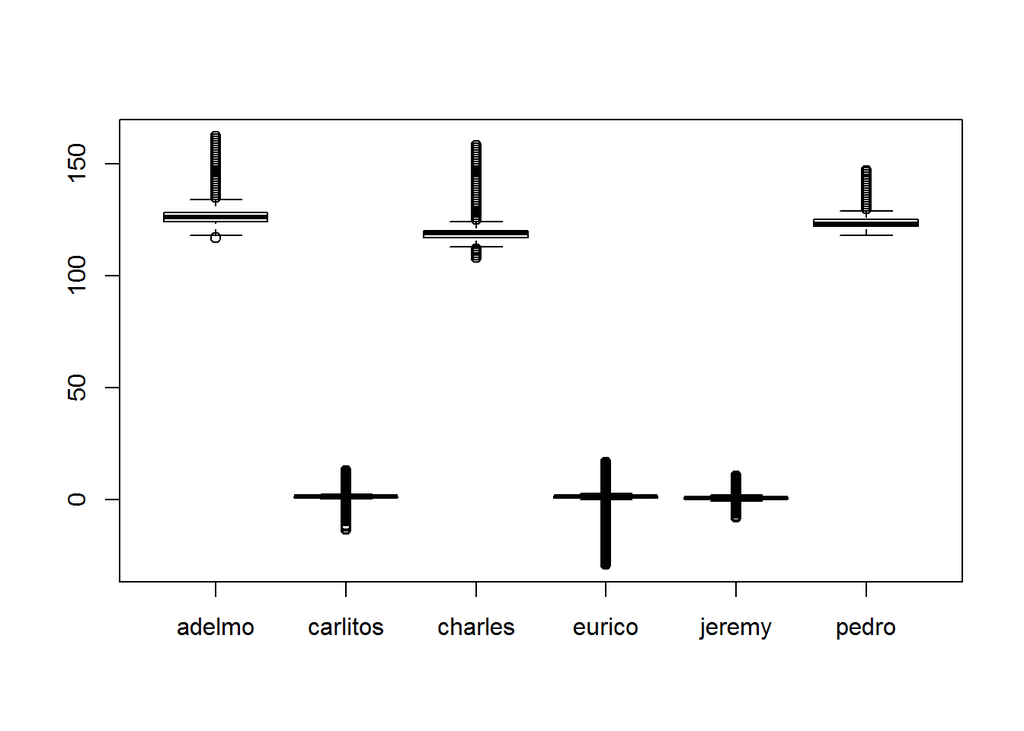

```r
boxplot(roll_belt ~ user_name, data=tr)
```

There is significant variation between users so it makes sense to keep user_name in the training. Otherwise we’ll have to normalize the features so that they become independant from user variablility. I’m not sure how to do this since I don’t have much understanding of human body movements.

## Training the Random Forest.

```r
fit <- train(classe ~ ., data=tr, method="rf")
```

The main problem I had with running random forest is the compuational time, I initially started with 10% sample for the training. Then tried 20% found out that the crossvalidation error was decreasing. It was pretty accurate with 50% data on the test set so I stopped there.

Let’s look at the generated model.

```
## Random Forest
##
## 9812 samples
##   57 predictor
##    5 classes: 'A', 'B', 'C', 'D', 'E'
##
## No pre-processing
## Resampling: Bootstrapped (25 reps)
##
## Summary of sample sizes: 9812, 9812, 9812, 9812, 9812, 9812, ...
##
## Resampling results across tuning parameters:
##
##   mtry  Accuracy  Kappa   Accuracy SD  Kappa SD
##    2    0.9823    0.9776  0.002187     0.002765
##   40    0.9965    0.9956  0.001157     0.001466
##   79    0.9946    0.9932  0.001780     0.002257
##
## Accuracy was used to select the optimal model using  the largest value.
## The final value used for the model was mtry = 40.
```

Prediction on the test set.

```r
res <- predict(fit, newdata = ts)
confusionMatrix(res,reference = ts$classe)
```

```
## Confusion Matrix and Statistics
##
##           Reference
## Prediction    A    B    C    D    E
##          A 2790    1    0    0    0
##          B    0 1893    2    0    0
##          C    0    4 1709    1    0
##          D    0    0    0 1607    3
##          E    0    0    0    0 1800
##
## Overall Statistics
##
##                Accuracy : 0.999
##                  95% CI : (0.998, 0.999)
##     No Information Rate : 0.284
##     P-Value [Acc > NIR] : <2e-16
##
##                   Kappa : 0.999
##  Mcnemar's Test P-Value : NA
##
## Statistics by Class:
##
##                      Class: A Class: B Class: C Class: D Class: E
## Sensitivity             1.000    0.997    0.999    0.999    0.998
## Specificity             1.000    1.000    0.999    1.000    1.000
## Pos Pred Value          1.000    0.999    0.997    0.998    1.000
## Neg Pred Value          1.000    0.999    1.000    1.000    1.000
## Prevalence              0.284    0.193    0.174    0.164    0.184
## Detection Rate          0.284    0.193    0.174    0.164    0.183
## Detection Prevalence    0.285    0.193    0.175    0.164    0.183
## Balanced Accuracy       1.000    0.999    0.999    1.000    0.999
```

Looking at the confusion matrix, The out of sample accuracy is 0.9989 which is almost same as the cross validation error. Thus, we can say that there is no overfitting and since the accuracy is high there is not bias too. In fact I managed to score 20/20 with this model in the submission section.